# EDA

Junxiu

2026-02-28

# Packages & Source functions

```r
library(tidyverse)
library(readxl)
library(janitor)
library(skimr)
library(naniar)
library(stringr)
library(genio)

source("function/load_functions.R")
```

# File path

```r
# phenotype
pheno_file1 <- file.path("data", "phenotype",
                         "CMS challenge Scotland 22G BE20041B sample IDs_with PCR11102022.xlsx")
pheno_file2 <- file.path("data", "phenotype",
                         "Data - CMS MOWI genetics project Scotland.xlsx")

# pedigree
ped_file <- file.path("data", "pedigree", "pedigree22G_CMSSalmoStrong.txt")

# genotype
bed_file <- file.path("data", "genotype", "2022CMSGeno_SalmoStrong.bed")
bim_file <- file.path("data", "genotype", "2022CMSGeno_SalmoStrong.bim")
fam_file <- file.path("data", "genotype", "2022CMSGeno_SalmoStrong.fam")
```

# EDA

## Phenotype

### Glimpse of the data

```r
pcr_pheno <- read_excel(pheno_file1, sheet = "Sheet2") %>%
  clean_names() %>%
  rename(
    fish_number = fish_nunber,
    test_replicate = test_replicate,
    tissue_type = tissue_type,
    reported_result = reported_result,
    cp_1 = cp_value_8,
    cp_2 = cp_value_9,
    cp_3 = cp_value_10
  ) %>%
  mutate(
    reported_result = as.factor(reported_result),
    tissue_type = as.factor(tissue_type),
    species = as.factor(species)
  )
head(pcr_pheno, 10)
```

```
## # A tibble: 10 × 11
##    sample_id sample_no    fish_number test_replicate species control tissue_type
##        <dbl> <chr>              <dbl>          <dbl> <fct>     <dbl> <fct>
##  1    418442 AFH-2022-02…           1              1 Salmo …    15.6 HE
##  2    418445 AFH-2022-02…           2              1 Salmo …    15.7 HE
##  3    418448 AFH-2022-02…           3              1 Salmo …    15.9 HE
##  4    418451 AFH-2022-02…           4              1 Salmo …    16.2 HE
##  5    418454 AFH-2022-02…           5              1 Salmo …    16.6 HE
##  6    418457 AFH-2022-02…           6              1 Salmo …    15.8 HE
##  7    418460 AFH-2022-02…           7              1 Salmo …    16.6 HE
##  8    418463 AFH-2022-02…           8              1 Salmo …    16.1 HE
##  9    418466 AFH-2022-02…           9              1 Salmo …    15.9 HE
## 10    418469 AFH-2022-02…          10              1 Salmo …    15.6 HE
## # ℹ 4 more variables: cp_1 <dbl>, cp_2 <dbl>, cp_3 <dbl>, reported_result <fct>
```

```r
histo_pheno <- read_excel(pheno_file2, sheet = "Scotland samples", skip = 1) %>%
  clean_names() %>%
  rename(
    id = id,
    atrium_area_background = area_background_2,
    atrium_area_inflamed = area_inflamed_tissue,
    atrium_area_rbc = area_red_blood_cells_4,
    atrium_area_noninflamed = area_non_inflamed_tissue_5,
    atrium_area_investigated = area_investigated_6,
    atrium_pct_inflam = percentage_inflammation,
    atrium_rel_inflam = relative_area_inflammation_8,
    spong_area_background = area_background_11,
    spong_area_inflamed = area_inflammed_tissue,
    spong_area_rbc = area_red_blood_cells_13,
    spong_area_noninflamed = area_non_inflamed_tissue_14,
    spong_area_investigated = area_investigated_15,
    spong_pct_inflam = precentage_inflammation,
    spong_rel_inflam = relative_area_inflammation_17,
    ratio_inflam = ratio_inflammation_atrium_spongiosum,
    ratio_control = ratio_controll
  )
head(histo_pheno, 10)
```

```
## # A tibble: 10 × 21
##    id                atrium_area_background atrium_area_inflamed atrium_area_rbc
##    <chr>                              <dbl>                <dbl>           <dbl>
##  1 2022_0221_001 (I…               1908031.                1626.         761586.
##  2 2022_0221_002 (I…               1901094.              127169.         265053.
##  3 2022_0221_003 (I…               4285250.               15960.         787437.
##  4 2022_0221_004 (I…               5203331.               21172.        2201792.
##  5 2022_0221_005 (I…               7199970.               16068.         526960.
##  6 2022_0221_006 (I…               4908302.                6844.        1864662.
##  7 2022_0221_007 (I…               1918802.               78857.         421232.
##  8 2022_0221_008 (I…               7153888.              183112.        1274345.
##  9 2022_0221_009 (I…               4707527.               15172.         493395.
## 10 2022_0221_010 (I…               1182745.                4916.         186654.
## # ℹ 17 more variables: atrium_area_noninflamed <dbl>,
## #   atrium_area_investigated <dbl>, atrium_pct_inflam <dbl>,
## #   atrium_rel_inflam <dbl>, note_9 <chr>, x10 <lgl>,
## #   spong_area_background <dbl>, spong_area_inflamed <dbl>,
## #   spong_area_rbc <dbl>, spong_area_noninflamed <dbl>,
## #   spong_area_investigated <dbl>, spong_pct_inflam <dbl>,
## #   spong_rel_inflam <dbl>, note_18 <chr>, x19 <lgl>, ratio_inflam <dbl>, …
```

```r
glimpse(pcr_pheno)
```

```
## Rows: 500
## Columns: 11
## $ sample_id       <dbl> 418442, 418445, 418448, 418451, 418454, 418457, 418460…
## $ sample_no       <chr> "AFH-2022-0221-F1-I-HEART_MG", "AFH-2022-0221-F2-I-HEA…
## $ fish_number     <dbl> 1, 2, 3, 4, 5, 6, 7, 8, 9, 10, 11, 12, 13, 14, 15, 16,…
## $ test_replicate  <dbl> 1, 1, 1, 1, 1, 1, 1, 1, 1, 1, 1, 1, 1, 1, 1, 1, 1, 1, …
## $ species         <fct> Salmo salar, Salmo salar, Salmo salar, Salmo salar, Sa…
## $ control         <dbl> 15.61, 15.69, 15.91, 16.18, 16.64, 15.76, 16.55, 16.12…
## $ tissue_type     <fct> HE, HE, HE, HE, HE, HE, HE, HE, HE, HE, HE, HE, HE, HE…
## $ cp_1            <dbl> 26.55, 29.90, 24.20, 27.99, 20.93, 24.58, 22.64, 16.35…
## $ cp_2            <dbl> 26.77, 30.21, 24.14, 28.04, 20.92, 24.43, 22.65, 16.32…
## $ cp_3            <dbl> 26.77, 30.04, 24.11, 27.88, 20.85, 24.43, 22.71, 16.27…
## $ reported_result <fct> POSITIVE, POSITIVE, POSITIVE, POSITIVE, POSITIVE, POSI…
```

```r
glimpse(histo_pheno)
```

```
## Rows: 500
## Columns: 21
## $ id                       <chr> "2022_0221_001 (Image 2)", "2022_0221_002 (Im…
## $ atrium_area_background   <dbl> 1908030.6, 1901093.9, 4285250.2, 5203331.3, 7…
## $ atrium_area_inflamed     <dbl> 1626.4692, 127169.1079, 15959.9249, 21172.151…
## $ atrium_area_rbc          <dbl> 761586.0, 265053.1, 787436.9, 2201792.0, 5269…
## $ atrium_area_noninflamed  <dbl> 4152175, 2577586, 5088500, 7359697, 6104357, …
## $ atrium_area_investigated <dbl> 6823419, 4870902, 10177147, 14785993, 1384735…
## $ atrium_pct_inflam        <dbl> 0.03915616, 4.70168726, 0.31266628, 0.2868517…
## $ atrium_rel_inflam        <dbl> 0.0003915616, 0.0470168726, 0.0031266628, 0.0…
## $ note_9                   <chr> NA, NA, NA, NA, NA, NA, NA, NA, NA, NA, NA, N…
## $ x10                      <lgl> NA, NA, NA, NA, NA, NA, NA, NA, NA, NA, NA, N…
## $ spong_area_background    <dbl> 2066947.2, 747823.6, 1794870.2, 2050954.7, 14…
## $ spong_area_inflamed      <dbl> 2702.6841, 2617.6731, 61157.6451, 21421.1641,…
## $ spong_area_rbc           <dbl> 1741507.60, 188953.48, 454298.49, 811569.99, …
## $ spong_area_noninflamed   <dbl> 23894748, 13882635, 21425906, 16333433, 18110…
## $ spong_area_investigated  <dbl> 27705906, 14822030, 23736232, 19217379, 20211…
## $ spong_pct_inflam         <dbl> 0.011309508, 0.018852181, 0.284625422, 0.1309…
## $ spong_rel_inflam         <dbl> 1.130951e-04, 1.885218e-04, 2.846254e-03, 1.3…
## $ note_18                  <chr> NA, NA, NA, NA, NA, NA, NA, NA, NA, NA, NA, N…
## $ x19                      <lgl> NA, NA, NA, NA, NA, NA, NA, NA, NA, NA, NA, N…
## $ ratio_inflam             <dbl> 3.4622335, 249.3975207, 1.0985185, 2.1900855,…
## $ ratio_control            <chr> NA, NA, NA, NA, "OK", NA, NA, "OK", NA, NA, N…
```

### Summary of the data

```r
skim(pcr_pheno)
```

Data summary

| Name | pcr_pheno |
| --- | --- |
| Number of rows | 500 |
| Number of columns | 11 |
| _______________________ |  |
| Column type frequency: |  |
| character | 1 |
| factor | 3 |
| numeric | 7 |
| ________________________ |  |
| Group variables | None |

**Variable type: character**

| skim_variable | n_missing | complete_rate | min | max | empty | n_unique | whitespace |
| --- | --- | --- | --- | --- | --- | --- | --- |
| sample_no | 0 | 1 | 27 | 29 | 0 | 500 | 0 |

**Variable type: factor**

| skim_variable | n_missing | complete_rate | ordered | n_unique | top_counts |
| --- | --- | --- | --- | --- | --- |
| species | 0 | 1 | FALSE | 1 | Sal: 500 |
| tissue_type | 0 | 1 | FALSE | 1 | HE: 500 |
| reported_result | 0 | 1 | FALSE | 2 | POS: 498, NEG: 2 |

**Variable type: numeric**

| skim_variable | n_missing | complete_rate | mean | sd | p0 | p25 | p50 | p75 | p100 | hist |
| --- | --- | --- | --- | --- | --- | --- | --- | --- | --- | --- |
| sample_id | 0 | 1 | 419790.50 | 853.79 | 418442.00 | 419116.25 | 419790.50 | 420464.75 | 421139.00 | ▇▇▇▇▇ |
| fish_number | 0 | 1 | 450.50 | 284.60 | 1.00 | 225.75 | 450.50 | 675.25 | 900.00 | ▇▇▇▇▇ |
| test_replicate | 0 | 1 | 1.17 | 0.37 | 1.00 | 1.00 | 1.00 | 1.00 | 2.00 | ▇▁▁▁▂ |
| control | 0 | 1 | 17.43 | 1.35 | 14.34 | 16.30 | 17.05 | 18.39 | 23.97 | ▅▇▅▁▁ |
| cp_1 | 0 | 1 | 27.10 | 3.24 | 0.00 | 25.67 | 27.52 | 29.09 | 37.97 | ▁▁▁▇▁ |
| cp_2 | 0 | 1 | 27.18 | 3.03 | 16.32 | 25.72 | 27.49 | 29.08 | 35.95 | ▁▂▇▆▁ |
| cp_3 | 0 | 1 | 27.03 | 3.45 | 0.00 | 25.66 | 27.44 | 29.12 | 34.63 | ▁▁▁▇▇ |

```r
skim(histo_pheno)
```

Data summary

| Name | histo_pheno |
| --- | --- |
| Number of rows | 500 |
| Number of columns | 21 |
| _______________________ |  |
| Column type frequency: |  |
| character | 4 |
| logical | 2 |
| numeric | 15 |
| ________________________ |  |
| Group variables | None |

**Variable type: character**

| skim_variable | n_missing | complete_rate | min | max | empty | n_unique | whitespace |
| --- | --- | --- | --- | --- | --- | --- | --- |
| id | 0 | 1.00 | 23 | 23 | 0 | 500 | 0 |
| note_9 | 488 | 0.02 | 17 | 75 | 0 | 5 | 0 |
| note_18 | 499 | 0.00 | 75 | 75 | 0 | 1 | 0 |
| ratio_control | 469 | 0.06 | 2 | 2 | 0 | 2 | 0 |

**Variable type: logical**

| skim_variable | n_missing | complete_rate | mean | count |
| --- | --- | --- | --- | --- |
| x10 | 500 | 0 | NaN | : |
| x19 | 500 | 0 | NaN | : |

**Variable type: numeric**

| skim_variable | n_missing | complete_rate | mean | sd | p0 | p25 | p50 | p75 | p100 | hist |
| --- | --- | --- | --- | --- | --- | --- | --- | --- | --- | --- |
| atrium_area_background | 0 | 1.00 | 2951520.37 | 1734152.22 | 0.00 | 1758651.26 | 2672065.56 | 3907867.34 | 10247954.22 | ▆▇▃▁▁ |
| atrium_area_inflamed | 0 | 1.00 | 170512.61 | 666363.14 | 0.00 | 11970.57 | 25109.19 | 73710.64 | 7567648.69 | ▇▁▁▁▁ |
| atrium_area_rbc | 0 | 1.00 | 850165.94 | 707380.05 | 0.00 | 326562.88 | 663107.24 | 1129083.22 | 4128964.19 | ▇▃▂▁▁ |
| atrium_area_noninflamed | 0 | 1.00 | 5731777.30 | 2615590.53 | 0.00 | 3925344.92 | 5441178.46 | 7163032.19 | 20393260.53 | ▃▇▂▁▁ |
| atrium_area_investigated | 0 | 1.00 | 9703964.71 | 4336367.34 | 0.00 | 6675107.28 | 9308268.67 | 12324497.82 | 28747509.95 | ▂▇▃▁▁ |
| atrium_pct_inflam | 6 | 0.99 | 2.44 | 7.84 | 0.01 | 0.23 | 0.51 | 1.22 | 89.24 | ▇▁▁▁▁ |
| atrium_rel_inflam | 6 | 0.99 | 0.02 | 0.08 | 0.00 | 0.00 | 0.01 | 0.01 | 0.89 | ▇▁▁▁▁ |
| spong_area_background | 0 | 1.00 | 1929358.68 | 1101283.26 | 256065.83 | 1115459.55 | 1691540.62 | 2443614.39 | 7284998.56 | ▇▆▂▁▁ |
| spong_area_inflamed | 0 | 1.00 | 42690.74 | 146857.03 | 382.63 | 7059.80 | 14748.26 | 34594.78 | 2273517.06 | ▇▁▁▁▁ |
| spong_area_rbc | 0 | 1.00 | 425337.22 | 319252.11 | 32387.19 | 202075.68 | 353033.30 | 553145.14 | 2171830.46 | ▇▃▁▁▁ |
| spong_area_noninflamed | 0 | 1.00 | 16507305.59 | 5687676.54 | 5285732.73 | 12226122.29 | 15826663.57 | 20160436.91 | 37210542.98 | ▅▇▆▂▁ |
| spong_area_investigated | 0 | 1.00 | 18904692.24 | 6659128.35 | 6030103.98 | 14070676.07 | 17844045.32 | 23252246.72 | 42541441.85 | ▅▇▆▂▁ |
| spong_pct_inflam | 0 | 1.00 | 0.25 | 0.68 | 0.00 | 0.04 | 0.10 | 0.20 | 10.63 | ▇▁▁▁▁ |
| spong_rel_inflam | 0 | 1.00 | 0.00 | 0.01 | 0.00 | 0.00 | 0.00 | 0.00 | 0.11 | ▇▁▁▁▁ |
| ratio_inflam | 2 | 1.00 | 12.27 | 37.14 | 0.00 | 2.75 | 5.83 | 11.10 | 719.92 | ▇▁▁▁▁ |

```r
# Whether there are replicate of ID and fish number
pcr_pheno %>% count(sample_id) %>% filter(n > 1)
```

```
## # A tibble: 0 × 2
## # ℹ 2 variables: sample_id <dbl>, n <int>
```

```r
pcr_pheno %>% count(fish_number) %>% filter(n > 1)
```

```
## # A tibble: 0 × 2
## # ℹ 2 variables: fish_number <dbl>, n <int>
```

```r
histo_pheno %>% count(id) %>% filter(n > 1)
```

```
## # A tibble: 0 × 2
## # ℹ 2 variables: id <chr>, n <int>
```

```r
# No!
```

### Distribution of Phenotype

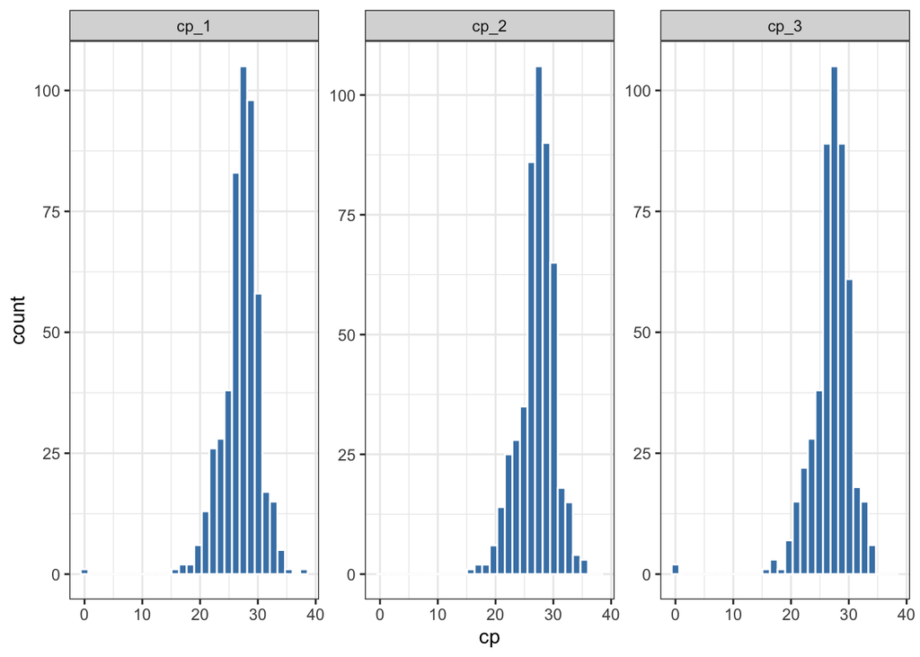

```r
pcr_pheno %>%
  pivot_longer(cols = c(cp_1, cp_2, cp_3), names_to = "rep", values_to = "cp") %>%
  ggplot(aes(x = cp)) +
  geom_histogram(bins = 30, fill = "steelblue", color = "white") +
  facet_wrap(~rep, scales = "free_y") +
  theme_bw()
```

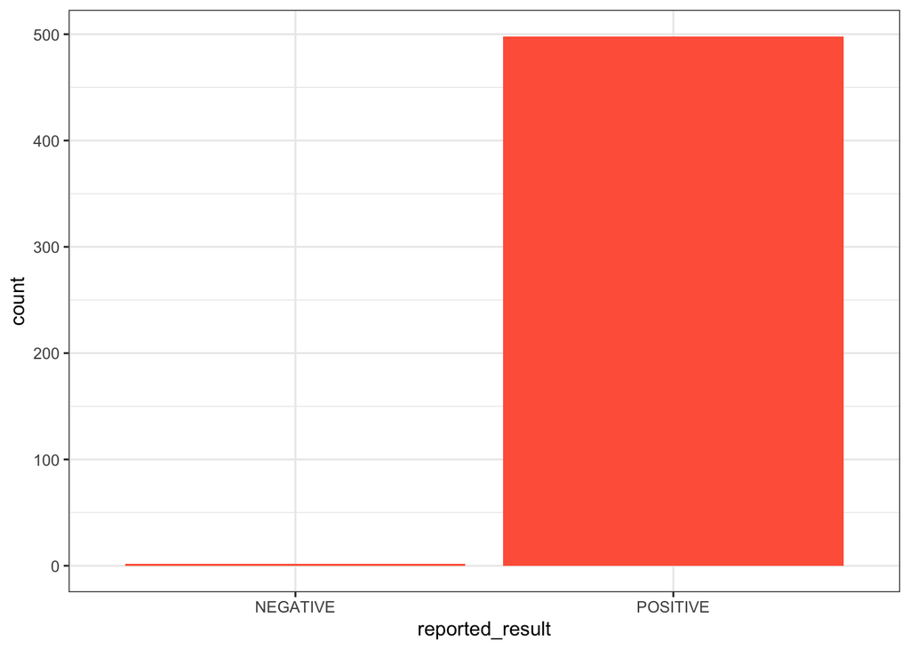

```r
pcr_pheno %>%
  ggplot(aes(x = reported_result)) +
  geom_bar(fill = "tomato") +
  theme_bw()
```

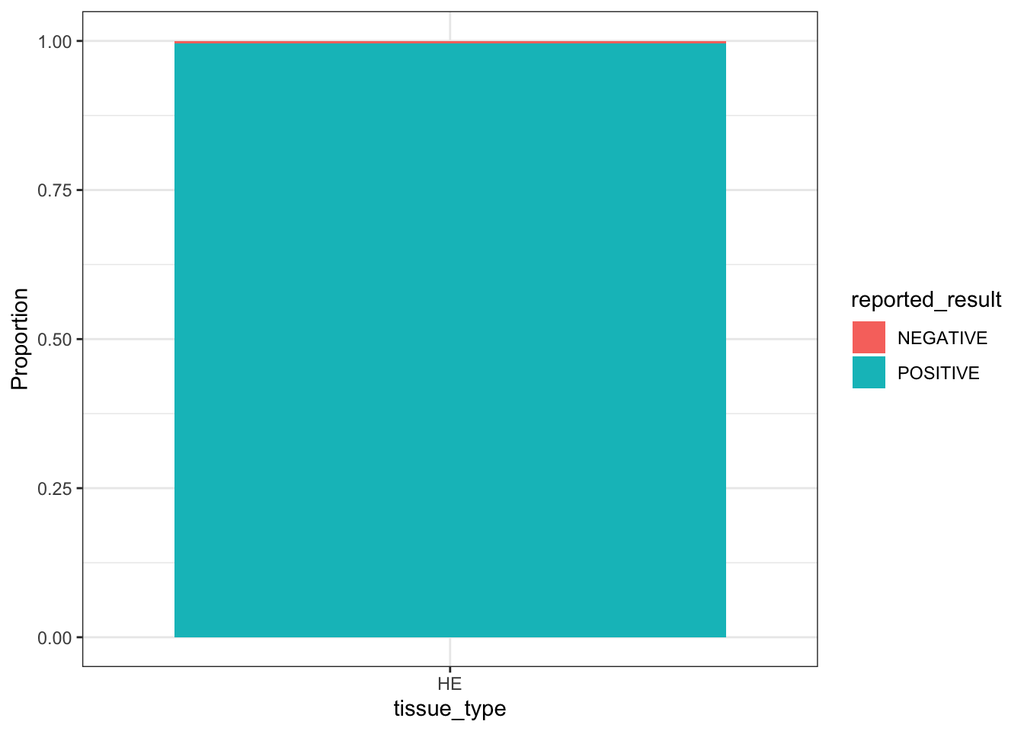

```r
pcr_pheno %>%
  ggplot(aes(x = tissue_type, fill = reported_result)) +
  geom_bar(position = "fill") +
  theme_bw() +
  ylab("Proportion")
```

Take a look at the `mean` and `median` of `Cp_value`

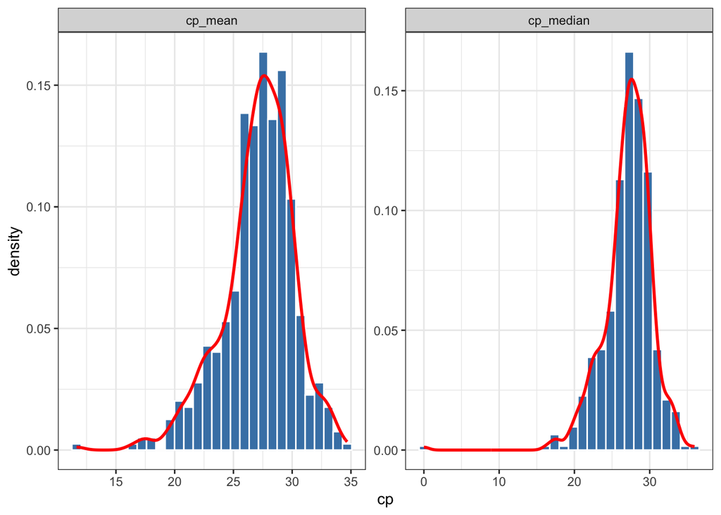

```r
pcr_pheno %>%
  mutate(
    cp_mean   = rowMeans(across(c(cp_1, cp_2, cp_3)), na.rm = TRUE),
    cp_median = apply(across(c(cp_1, cp_2, cp_3)), 1, median, na.rm = TRUE)
  ) %>%
  select(cp_mean, cp_median) %>%
  pivot_longer(cols = everything(), names_to = "summary_type", values_to = "cp") %>%
  ggplot(aes(x = cp)) +
  geom_histogram(aes(y = after_stat(density)),
                 bins = 30,
                 fill = "steelblue",
                 color = "white") +
  geom_density(color = "red", linewidth = 1) +
  facet_wrap(~summary_type, scales = "free") +
  theme_bw()
```

We could see a little left skew for both mean and median value of the `Cp_value`.

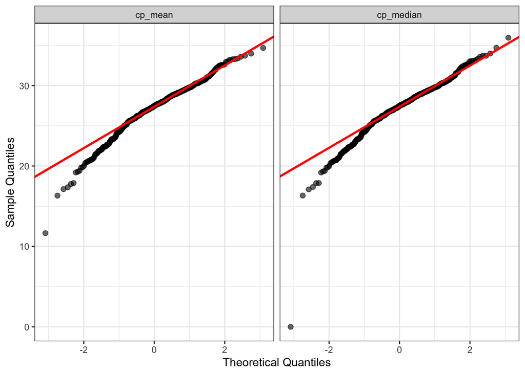

```r
pcr_pheno %>%
  mutate(
    cp_mean   = rowMeans(across(c(cp_1, cp_2, cp_3)), na.rm = TRUE),
    cp_median = apply(across(c(cp_1, cp_2, cp_3)), 1, median, na.rm = TRUE)
  ) %>%
  select(cp_mean, cp_median) %>%
  pivot_longer(everything(), names_to = "trait", values_to = "cp") %>%
  ggplot(aes(sample = cp)) +
  stat_qq(size = 2, alpha = 0.6) +
  stat_qq_line(color = "red", linewidth = 1) +
  facet_wrap(~trait) +
  theme_bw() +
  labs(
    x = "Theoretical Quantiles",
    y = "Sample Quantiles"
  )
```

### Distribution of histopathology

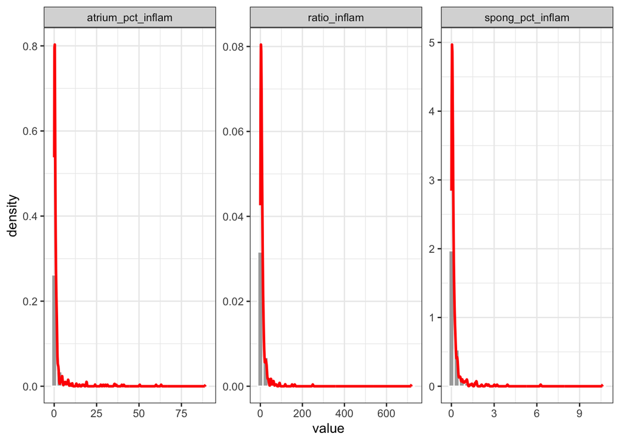

```r
histo_pheno %>%
  select(atrium_pct_inflam, spong_pct_inflam, ratio_inflam) %>%
  pivot_longer(everything(), names_to = "trait", values_to = "value") %>%
  ggplot(aes(x = value)) +
  geom_histogram(aes(y = after_stat(density)),
                 bins = 30,
                 fill = "darkgrey",
                 color = "white") +
  geom_density(color = "red", linewidth = 1) +
  facet_wrap(~trait, scales = "free") +
  theme_bw()
```

Consider the data transformation: take `log` value.

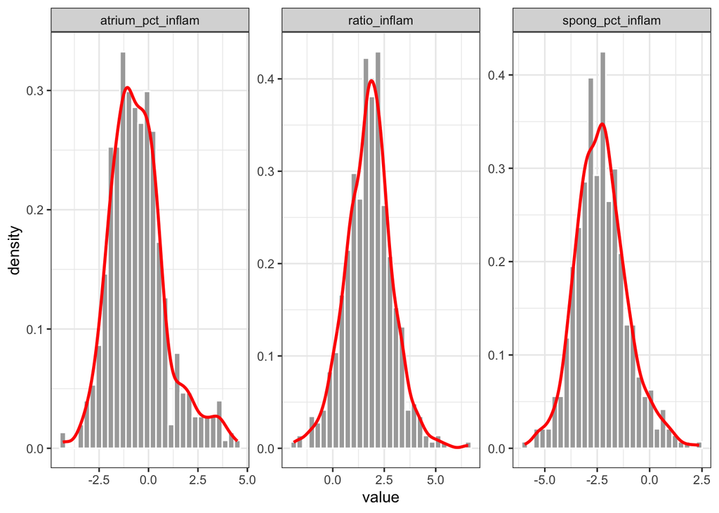

```r
histo_pheno %>%
  select(atrium_pct_inflam, spong_pct_inflam, ratio_inflam) %>%
  pivot_longer(everything(), names_to = "trait", values_to = "value") %>%
  mutate(value = log(value)) %>%
  ggplot(aes(x = value)) +
  geom_histogram(aes(y = after_stat(density)),
                 bins = 30,
                 fill = "darkgrey",
                 color = "white") +
  geom_density(color = "red", linewidth = 1) +
  facet_wrap(~trait, scales = "free") +
  theme_bw()
```

```r
# Calculate cp mean, sd
# Calculate inflam differ and mean

pcr_pheno <- pcr_pheno %>%
  mutate(
    cp_mean = rowMeans(select(., cp_1, cp_2, cp_3), na.rm = TRUE),
    cp_sd = apply(select(., cp_1, cp_2, cp_3), 1, sd, na.rm = TRUE)
  )

histo_pheno <- histo_pheno %>%
  mutate(
    inflam_diff = atrium_pct_inflam - spong_pct_inflam,
    inflam_mean = (atrium_pct_inflam + spong_pct_inflam) / 2
  )

summary(pcr_pheno$cp_mean)
```

```
##    Min. 1st Qu.  Median    Mean 3rd Qu.    Max.
##   11.65   25.64   27.45   27.10   29.10   34.68
```

```r
cat("\n")
```

```r
summary(pcr_pheno$cp_sd)
```

```
##      Min.   1st Qu.    Median      Mean   3rd Qu.      Max.
##  0.005774  0.047258  0.081854  0.204116  0.136504 21.362755
```

```r
cat("\n")
```

```r
summary(histo_pheno$inflam_diff)
```

```
##    Min. 1st Qu.  Median    Mean 3rd Qu.    Max.    NA's
## -8.5789  0.1350  0.3739  2.1863  0.9814 86.7566       6
```

From the result above, the max of $\text{cp_sd}$ value could be 21 which is a little bit large which can be think of as outlier. Double check:

```r
pcr_pheno %>%
    arrange(desc(cp_sd)) %>%
    select(sample_id, sample_no, cp_1, cp_2, cp_3, cp_mean, cp_sd) %>%
    head(20)
```

```
## # A tibble: 20 × 7
##    sample_id sample_no                      cp_1  cp_2  cp_3 cp_mean  cp_sd
##        <dbl> <chr>                         <dbl> <dbl> <dbl>   <dbl>  <dbl>
##  1    420500 AFH-2022-0221-F687-I-HEART_MG  38.0  36.0   0      24.6 21.4
##  2    418601 AFH-2022-0221-F54-I-HEART_MG    0    34.9   0      11.6 20.2
##  3    419915 AFH-2022-0221-F492-I-HEART_MG  28.3  28.3  31.2    29.3  1.71
##  4    421046 AFH-2022-0221-F869-I-HEART_MG  29.8  29.9  32.4    30.7  1.48
##  5    418532 AFH-2022-0221-F31-I-HEART_MG   29.1  26.2  28.0    27.8  1.44
##  6    418523 AFH-2022-0221-F28-I-HEART_MG   27.3  29.0  27.3    27.9  1.00
##  7    420425 AFH-2022-0221-F662-I-HEART_MG  24.6  26.0  24.5    25.0  0.862
##  8    420494 AFH-2022-0221-F685-I-HEART_MG  28.1  26.9  26.8    27.3  0.688
##  9    418517 AFH-2022-0221-F26-I-HEART_MG   34.1  33.0  32.8    33.3  0.684
## 10    418502 AFH-2022-0221-F21-I-HEART_MG   32.3  33.0  33.5    32.9  0.599
## 11    418664 AFH-2022-0221-F75-I-HEART_MG   33.8  32.7  33.1    33.2  0.584
## 12    418556 AFH-2022-0221-F39-I-HEART_MG   30.2  31.1  30.4    30.6  0.496
## 13    420935 AFH-2022-0221-F832-I-HEART_MG  28.4  29.2  29.1    28.9  0.455
## 14    420896 AFH-2022-0221-F819-I-HEART_MG  32.4  32.0  31.5    32.0  0.453
## 15    420398 AFH-2022-0221-F653-I-HEART_MG  32.8  33.6  33.6    33.4  0.448
## 16    419930 AFH-2022-0221-F497-I-HEART_MG  33.7  33.1  33.9    33.6  0.440
## 17    421037 AFH-2022-0221-F866-I-HEART_MG  29.9  30.6  29.8    30.1  0.428
## 18    419882 AFH-2022-0221-F481-I-HEART_MG  29.8  29.0  29.3    29.4  0.422
## 19    419894 AFH-2022-0221-F485-I-HEART_MG  29.0  29.6  28.9    29.1  0.407
## 20    420509 AFH-2022-0221-F690-I-HEART_MG  29.8  30.2  30.6    30.2  0.405
```

We can see that $\text{sample_ID}$ which 420500 and 418601 have abnormal $\text{cp_value}$.

Two proposed methods:

1. change 0 to ‘NA’
2. See reported_result as categorical variable?

Now, we look at the $\text{histo_pheno}$:

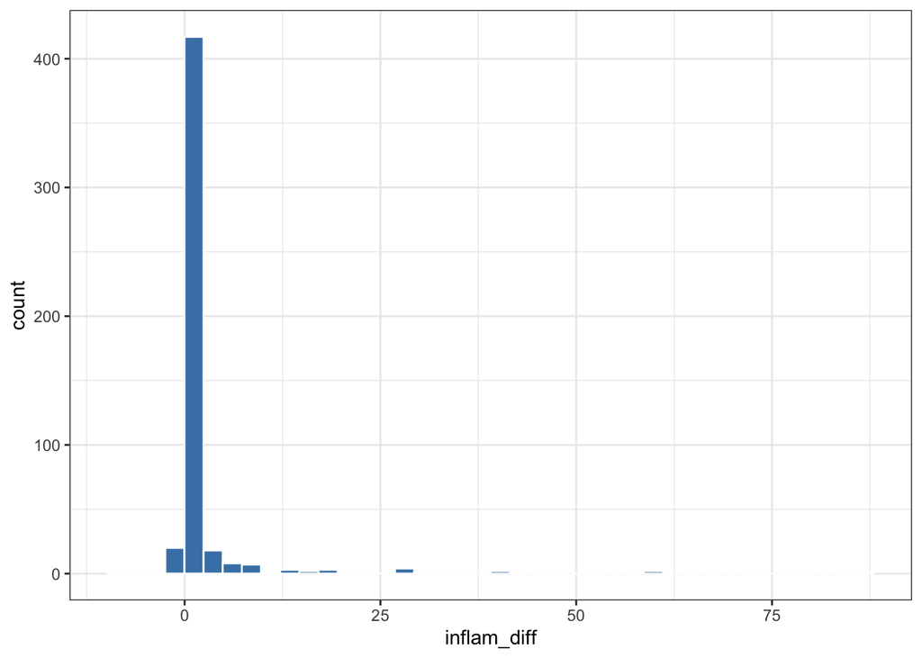

```r
histo_pheno %>%
  ggplot(aes(x = inflam_diff)) +
  geom_histogram(bins = 40, fill = "steelblue", color = "white") +
  theme_bw()
```

```r
histo_pheno %>%
  arrange(desc(inflam_diff)) %>%
  select(id, atrium_pct_inflam, spong_pct_inflam, inflam_diff) %>%
  head(50)
```

```
## # A tibble: 50 × 4
##    id                      atrium_pct_inflam spong_pct_inflam inflam_diff
##    <chr>                               <dbl>            <dbl>       <dbl>
##  1 2022_0221_073 (Image 2)              89.2            2.48         86.8
##  2 2022_0221_379 (Image 2)              63.1            3.01         60.0
##  3 2022_0221_218 (Image 2)              60.1            1.10         59.0
##  4 2022_0221_035 (Image 2)              50.4            1.76         48.7
##  5 2022_0221_078 (Image 2)              41.1            1.07         40.0
##  6 2022_0221_368 (Image 2)              39.9            0.621        39.2
##  7 2022_0221_327 (Image 2)              36.6            1.13         35.5
##  8 2022_0221_121 (Image 2)              35.8            2.61         33.1
##  9 2022_0221_137 (Image 2)              31.4            0.761        30.6
## 10 2022_0221_125 (Image 2)              35.4            6.27         29.2
## # ℹ 40 more rows
```

We notice that there are 6 NAs, now we find them:

```r
histo_pheno %>%
  summarise(
    n_missing_atrium = sum(is.na(atrium_pct_inflam)),
    n_missing_spong = sum(is.na(spong_pct_inflam)),
    n_missing_diff = sum(is.na(inflam_diff))
  )
```

```
## # A tibble: 1 × 3
##   n_missing_atrium n_missing_spong n_missing_diff
##              <int>           <int>          <int>
## 1                6               0              6
```

```r
histo_pheno %>%
  filter(is.na(inflam_diff)) %>%
  select(id, atrium_pct_inflam, spong_pct_inflam)
```

```
## # A tibble: 6 × 3
##   id                      atrium_pct_inflam spong_pct_inflam
##   <chr>                               <dbl>            <dbl>
## 1 2022_0221_115 (Image 2)                NA           0.116
## 2 2022_0221_130 (Image 2)                NA           0.0192
## 3 2022_0221_375 (Image 2)                NA           0.0441
## 4 2022_0221_383 (Image 2)                NA           0.0610
## 5 2022_0221_431 (Image 2)                NA           0.0260
## 6 2022_0221_491 (Image 2)                NA           0.0439
```

We find that 2022_0221_115, 130, 375, 383, 431, 491 are missing $\text{atrium_pct_inflam}$ value.

### Join the phenotype IDs

```r
pcr_pheno2 <- pcr_pheno %>%
  mutate(
    batch = str_extract(sample_no, "\\d{4}-\\d{4}"),
    fish_n = as.integer(str_extract(sample_no, "(?<=-F)\\d+")),
    fish3  = str_pad(fish_n, width = 3, pad = "0"),
    id_key = paste0(str_replace_all(batch, "-", "_"), "_", fish3)
  )


histo_pheno2 <- histo_pheno %>%
  mutate(
    batch = str_extract(id, "\\d{4}_\\d{4}"),
    fish_n = as.integer(str_extract(id, "(?<=_)\\d+(?=\\s*\\()")),
    fish3 = str_pad(fish_n, 3, pad = "0"),
    id_key = paste0(batch, "_", fish3)
  )

pheno_joined <- pcr_pheno2 %>%
  left_join(histo_pheno2, by = "id_key")
```

We now get the **joined form** $\text{pheno_joined}$

```r
head(pheno_joined, 20)
```

```
## # A tibble: 20 × 43
##    sample_id sample_no    fish_number test_replicate species control tissue_type
##        <dbl> <chr>              <dbl>          <dbl> <fct>     <dbl> <fct>
##  1    418442 AFH-2022-02…           1              1 Salmo …    15.6 HE
##  2    418445 AFH-2022-02…           2              1 Salmo …    15.7 HE
##  3    418448 AFH-2022-02…           3              1 Salmo …    15.9 HE
##  4    418451 AFH-2022-02…           4              1 Salmo …    16.2 HE
##  5    418454 AFH-2022-02…           5              1 Salmo …    16.6 HE
##  6    418457 AFH-2022-02…           6              1 Salmo …    15.8 HE
##  7    418460 AFH-2022-02…           7              1 Salmo …    16.6 HE
##  8    418463 AFH-2022-02…           8              1 Salmo …    16.1 HE
##  9    418466 AFH-2022-02…           9              1 Salmo …    15.9 HE
## 10    418469 AFH-2022-02…          10              1 Salmo …    15.6 HE
## 11    418472 AFH-2022-02…          11              1 Salmo …    16.3 HE
## 12    418475 AFH-2022-02…          12              1 Salmo …    16.4 HE
## 13    418478 AFH-2022-02…          13              1 Salmo …    16.1 HE
## 14    418481 AFH-2022-02…          14              1 Salmo …    15.4 HE
## 15    418484 AFH-2022-02…          15              1 Salmo …    15.6 HE
## 16    418487 AFH-2022-02…          16              1 Salmo …    16.5 HE
## 17    418490 AFH-2022-02…          17              1 Salmo …    16.1 HE
## 18    418493 AFH-2022-02…          18              1 Salmo …    15.8 HE
## 19    418496 AFH-2022-02…          19              1 Salmo …    16.2 HE
## 20    418499 AFH-2022-02…          20              1 Salmo …    16   HE
## # ℹ 36 more variables: cp_1 <dbl>, cp_2 <dbl>, cp_3 <dbl>,
## #   reported_result <fct>, cp_mean <dbl>, cp_sd <dbl>, batch.x <chr>,
## #   fish_n.x <int>, fish3.x <chr>, id_key <chr>, id <chr>,
## #   atrium_area_background <dbl>, atrium_area_inflamed <dbl>,
## #   atrium_area_rbc <dbl>, atrium_area_noninflamed <dbl>,
## #   atrium_area_investigated <dbl>, atrium_pct_inflam <dbl>,
## #   atrium_rel_inflam <dbl>, note_9 <chr>, x10 <lgl>, …
```

### Build phenotype-to-pedigree (from Sheet1)

`Sheet1` contains `animal/sire/dam` fields and is used as the bridge from phenotype IDs to pedigree IDs.

```r
normalize_cms_id <- function(x) {
  x <- as.character(x)
  x[x %in% c("", "NA", "NaN", "0", "2")] <- NA_character_

  # Animal IDs in Sheet1 miss "00" after ICM
  x <- str_replace(x, "^2022IRS1ICMFR", "2022IRS1ICM00FR")

  # Parent IDs in Sheet1 miss "0000" after CBN to fit pedigree
  x <- str_replace(x, "^2018IRS1CBN([0-9]{5}[A-Z][0-9]{2})$", "2018IRS1CBN0000\\1")
  x
}

sheet1_map <- read_excel(pheno_file1, sheet = "Sheet1") %>%
  clean_names() %>%
  transmute(
    sample_id = as.character(sample_id),
    fish_no = suppressWarnings(as.integer(fish_no)),
    histo_cassette_id = histo_cassette_id,
    histo_key = if_else(
      !is.na(histo_cassette_id),
      paste0(
        str_replace_all(str_extract(histo_cassette_id, "^\\d{4}/\\d{4}"), "/", "_"),
        "_",
        str_pad(as.integer(str_extract(histo_cassette_id, "\\d+$")), 3, pad = "0")
      ),
      NA_character_
    ),
    genotyping_tube_id = genotyping_tube_id,
    animal = normalize_cms_id(animal),
    sire = normalize_cms_id(sire),
    dam = normalize_cms_id(dam)
  ) %>%
  distinct(sample_id, .keep_all = TRUE)
pheno_ped <- pheno_joined %>%
  mutate(sample_id = as.character(sample_id)) %>%
  left_join(sheet1_map, by = "sample_id")
```

```r
head(pheno_ped, 50)
```

```
## # A tibble: 50 × 50
##    sample_id sample_no    fish_number test_replicate species control tissue_type
##    <chr>     <chr>              <dbl>          <dbl> <fct>     <dbl> <fct>
##  1 418442    AFH-2022-02…           1              1 Salmo …    15.6 HE
##  2 418445    AFH-2022-02…           2              1 Salmo …    15.7 HE
##  3 418448    AFH-2022-02…           3              1 Salmo …    15.9 HE
##  4 418451    AFH-2022-02…           4              1 Salmo …    16.2 HE
##  5 418454    AFH-2022-02…           5              1 Salmo …    16.6 HE
##  6 418457    AFH-2022-02…           6              1 Salmo …    15.8 HE
##  7 418460    AFH-2022-02…           7              1 Salmo …    16.6 HE
##  8 418463    AFH-2022-02…           8              1 Salmo …    16.1 HE
##  9 418466    AFH-2022-02…           9              1 Salmo …    15.9 HE
## 10 418469    AFH-2022-02…          10              1 Salmo …    15.6 HE
## # ℹ 40 more rows
## # ℹ 43 more variables: cp_1 <dbl>, cp_2 <dbl>, cp_3 <dbl>,
## #   reported_result <fct>, cp_mean <dbl>, cp_sd <dbl>, batch.x <chr>,
## #   fish_n.x <int>, fish3.x <chr>, id_key <chr>, id <chr>,
## #   atrium_area_background <dbl>, atrium_area_inflamed <dbl>,
## #   atrium_area_rbc <dbl>, atrium_area_noninflamed <dbl>,
## #   atrium_area_investigated <dbl>, atrium_pct_inflam <dbl>, …
```

## Pedigree Information

```r
pedigree <- read_table(ped_file, col_types = cols(
  id = col_character(),
  sire = col_character(),
  dam = col_character(),
  sibgroup = col_character(),
  YC = col_double()
)) %>%
  mutate(
    sire = na_if(sire, "0"),
    dam = na_if(dam, "0"),
    is_founder = is.na(sire) & is.na(dam),
    n_known_parents = (!is.na(sire)) + (!is.na(dam))
  )
```

Have a look at the pedigree structure:

```r
head(pedigree, 20)
```

```
## # A tibble: 20 × 7
##    id                      sire  dam   sibgroup    YC is_founder n_known_parents
##    <chr>                   <chr> <chr> <chr>    <dbl> <lgl>                <int>
##  1 1997NOS1CBN000000G0P1B5 <NA>  <NA>  S1CBN     1997 TRUE                     0
##  2 1997NOS1CBN000000G0P1B9 <NA>  <NA>  S1CBN     1997 TRUE                     0
##  3 1997NOS1CBN00000G0P1307 <NA>  <NA>  S1CBN     1997 TRUE                     0
##  4 1997NOS1CBN00000G0P1339 <NA>  <NA>  S1CBN     1997 TRUE                     0
##  5 1997NOS1CBN00000G0P1357 <NA>  <NA>  S1CBN     1997 TRUE                     0
##  6 1997NOS1CBN00000G0P1417 <NA>  <NA>  S1CBN     1997 TRUE                     0
##  7 1997NOS1CBN00000G0P1519 <NA>  <NA>  S1CBN     1997 TRUE                     0
##  8 1997NOS1CBN00000G0P1523 <NA>  <NA>  S1CBN     1997 TRUE                     0
##  9 1997NOS1CBN00000G0P1532 <NA>  <NA>  S1CBN     1997 TRUE                     0
## 10 1997NOS1CBN00000G0P1534 <NA>  <NA>  S1CBN     1997 TRUE                     0
## 11 1997NOS1CBN00000G0P1622 <NA>  <NA>  S1CBN     1997 TRUE                     0
## 12 1997NOS1CBN00000G0P1624 <NA>  <NA>  S1CBN     1997 TRUE                     0
## 13 1997NOS1CBN00000G0P1630 <NA>  <NA>  S1CBN     1997 TRUE                     0
## 14 1997NOS1CBN00000G0P1653 <NA>  <NA>  S1CBN     1997 TRUE                     0
## 15 1997NOS1CBN00000G0P1B15 <NA>  <NA>  S1CBN     1997 TRUE                     0
## 16 1997NOS1CBN00000G0P1B16 <NA>  <NA>  S1CBN     1997 TRUE                     0
## 17 1997NOS1CBN00000G0P1B21 <NA>  <NA>  S1CBN     1997 TRUE                     0
## 18 1997NOS1CBN00000G0P1B39 <NA>  <NA>  S1CBN     1997 TRUE                     0
## 19 1997NOS1CBN00000G0P1G31 <NA>  <NA>  S1CBN     1997 TRUE                     0
## 20 1997NOS1CBN00000G0P1G46 <NA>  <NA>  S1CBN     1997 TRUE                     0
```

```r
tail(pedigree, 20)
```

```
## # A tibble: 20 × 7
##    id                      sire  dam   sibgroup    YC is_founder n_known_parents
##    <chr>                   <chr> <chr> <chr>    <dbl> <lgl>                <int>
##  1 2022IRS1ICM00FR39780004 2018… 2018… S1ICM     2022 FALSE                    2
##  2 2022IRS1ICM00FR39780005 2018… 2018… S1ICM     2022 FALSE                    2
##  3 2022IRS1ICM00FR39780006 2018… 2018… S1ICM     2022 FALSE                    2
##  4 2022IRS1ICM00FR39780007 2018… 2018… S1ICM     2022 FALSE                    2
##  5 2022IRS1ICM00FR39780008 <NA>  2018… S1ICM     2022 FALSE                    1
##  6 2022IRS1ICM00FR39780009 2018… 2018… S1ICM     2022 FALSE                    2
##  7 2022IRS1ICM00FR39780010 2018… 2018… S1ICM     2022 FALSE                    2
##  8 2022IRS1ICM00FR39780011 2018… 2018… S1ICM     2022 FALSE                    2
##  9 2022IRS1ICM00FR39780012 2018… 2018… S1ICM     2022 FALSE                    2
## 10 2022IRS1ICM00FR39780013 2018… 2018… S1ICM     2022 FALSE                    2
## 11 2022IRS1ICM00FR39780014 2018… 2018… S1ICM     2022 FALSE                    2
## 12 2022IRS1ICM00FR39780015 2018… 2018… S1ICM     2022 FALSE                    2
## 13 2022IRS1ICM00FR39780016 <NA>  <NA>  S1ICM     2022 TRUE                     0
## 14 2022IRS1ICM00FR39780017 2018… 2018… S1ICM     2022 FALSE                    2
## 15 2022IRS1ICM00FR39780018 2018… 2018… S1ICM     2022 FALSE                    2
## 16 2022IRS1ICM00FR39780019 2018… 2018… S1ICM     2022 FALSE                    2
## 17 2022IRS1ICM00FR39780020 2018… 2018… S1ICM     2022 FALSE                    2
## 18 2022IRS1ICM00FR39780021 2018… 2018… S1ICM     2022 FALSE                    2
## 19 2022IRS1ICM00FR39780022 2018… 2018… S1ICM     2022 FALSE                    2
## 20 2022IRS1ICM00FR39780023 2018… 2018… S1ICM     2022 FALSE                    2
```

Some summary of pedigree information:

```r
qgm_ped_summary(pedigree[,1:3])
```

```
## [1] "Pedigree assumed ordered id, sire, dam in columns 1 to 3"
## [1] "Number of distinct ids: 3051"
## [1] " ... Maximum number of records per id: 1"
## [1] " ... Minimum number of records per id: 1"
## [1] " ... Number of distinct ids with no sire: 244"
## [1] " ... Number of distinct ids with no dam : 264"
## [1] " ... Number of distinct ids with no sire or dam: 321"
## [1] "Number of distinct sires: 335"
## [1] " ... Maximum offspring per sire : 120"
## [1] " ... Minimum offspring per sire : 1"
## [1] "Number of distinct dams : 441"
## [1] " ... Maximum offspring per dam : 71"
## [1] " ... Minimum offspring per dam : 1"
## [1] "Number of mating pairs: 477"
## [1] " ... Maximum number of sires per dam: 3"
## [1] " ... Minimum number of sires per dam: 1"
## [1] " ... Maximum number of dams per sire: 4"
## [1] " ... Minimum number of dams per sire: 1"
## [1] " ... Maximum number of offspring per pair: 71"
## [1] " ... Minimum number of offspring per pair: 1"
## [1] "Number of parents used as both sires and dams: 0"
## [1] "Number of parents used for selfing: 0"
```

From the result, we could see that there are 3051 different individuals, no multiple IDs. Quite clean!

Quite a lot missing parents information.

```r
# Some summary statistics about pedigree
pedigree %>%
  summarise(
    n_animals = n(),
    n_unique_id = n_distinct(id),
    n_founders = sum(is_founder),
    n_non_founders = sum(!is_founder),
    n_two_known_parents = sum(n_known_parents == 2),
    n_one_known_parent = sum(n_known_parents == 1),
    n_no_known_parent = sum(n_known_parents == 0)
  )
```

```
## # A tibble: 1 × 7
##   n_animals n_unique_id n_founders n_non_founders n_two_known_parents
##       <int>       <int>      <int>          <int>               <int>
## 1      3051        3051        187           2864                2730
## # ℹ 2 more variables: n_one_known_parent <int>, n_no_known_parent <int>
```

```r
pedigree %>%
  count(sibgroup, sort = TRUE) %>%
  head(15)
```

```
## # A tibble: 3 × 2
##   sibgroup     n
##   <chr>    <int>
## 1 S1CBN     2067
## 2 S1ICM      980
## 3 S1CBI        4
```

```r
pedigree %>%
  count(YC, sort = TRUE)
```

```
## # A tibble: 20 × 2
##       YC     n
##    <dbl> <int>
##  1  2022  2274
##  2  2018   219
##  3  2014   114
##  4  2002    77
##  5  2010    77
##  6  2006    63
##  7  1998    62
##  8  1997    38
##  9  2001    26
## 10  2000    20
## 11  1999    14
## 12  2005    14
## 13  2004    11
## 14  2003    10
## 15  2009     9
## 16  2008     7
## 17  2007     6
## 18  2012     4
## 19  2011     3
## 20  2013     3
```

```r
# Read Plink files (bim/fam/bed)
plink_obj <- read_plink(tools::file_path_sans_ext(bed_file))
```

```
## Reading: data/genotype/2022CMSGeno_SalmoStrong.bim
```

```
## Reading: data/genotype/2022CMSGeno_SalmoStrong.fam
```

```
## Reading: data/genotype/2022CMSGeno_SalmoStrong.bed
```

```r
geno <- plink_obj$X
bim <- plink_obj$bim
fam <- plink_obj$fam
```

```r
head(fam, 10)
```

```
## # A tibble: 10 × 6
##    fam                     id                      pat   mat     sex pheno
##    <chr>                   <chr>                   <chr> <chr> <int> <dbl>
##  1 2022IRS1ICM000000000961 2022IRS1ICM000000000961 0     0         0    -9
##  2 2022IRS1ICM000000000962 2022IRS1ICM000000000962 0     0         0    -9
##  3 2022IRS1ICM000000000963 2022IRS1ICM000000000963 0     0         0    -9
##  4 2022IRS1ICM000000000964 2022IRS1ICM000000000964 0     0         0    -9
##  5 2022IRS1ICM000000000965 2022IRS1ICM000000000965 0     0         0    -9
##  6 2022IRS1ICM000000000966 2022IRS1ICM000000000966 0     0         0    -9
##  7 2022IRS1ICM000000000967 2022IRS1ICM000000000967 0     0         0    -9
##  8 2022IRS1ICM000000000968 2022IRS1ICM000000000968 0     0         0    -9
##  9 2022IRS1ICM000000000969 2022IRS1ICM000000000969 0     0         0    -9
## 10 2022IRS1ICM000000000970 2022IRS1ICM000000000970 0     0         0    -9
```

```r
head(bim, 10)
```

```
## # A tibble: 10 × 6
##    chr   id           posg    pos alt   ref
##    <chr> <chr>       <dbl>  <int> <chr> <chr>
##  1 1     AX-87101513     0 107201 A     G
##  2 1     AX-97898780     0 428343 A     G
##  3 1     AX-97895216     0 428897 A     G
##  4 1     AX-97891331     0 498835 A     G
##  5 1     AX-98298674     0 499892 T     G
##  6 1     AX-88243204     0 549538 G     A
##  7 1     AX-96476823     0 587862 C     T
##  8 1     AX-98297057     0 588203 G     A
##  9 1     AX-87004556     0 603864 T     C
## 10 1     AX-98305370     0 614931 T     C
```

```r
tail(fam, 10)
```

```
## # A tibble: 10 × 6
##    fam                     id                      pat   mat     sex pheno
##    <chr>                   <chr>                   <chr> <chr> <int> <dbl>
##  1 2022IRS1ICM00FR39780014 2022IRS1ICM00FR39780014 0     0         0    -9
##  2 2022IRS1ICM00FR39780015 2022IRS1ICM00FR39780015 0     0         0    -9
##  3 2022IRS1ICM00FR39780016 2022IRS1ICM00FR39780016 0     0         0    -9
##  4 2022IRS1ICM00FR39780017 2022IRS1ICM00FR39780017 0     0         0    -9
##  5 2022IRS1ICM00FR39780018 2022IRS1ICM00FR39780018 0     0         0    -9
##  6 2022IRS1ICM00FR39780019 2022IRS1ICM00FR39780019 0     0         0    -9
##  7 2022IRS1ICM00FR39780020 2022IRS1ICM00FR39780020 0     0         0    -9
##  8 2022IRS1ICM00FR39780021 2022IRS1ICM00FR39780021 0     0         0    -9
##  9 2022IRS1ICM00FR39780022 2022IRS1ICM00FR39780022 0     0         0    -9
## 10 2022IRS1ICM00FR39780023 2022IRS1ICM00FR39780023 0     0         0    -9
```

```r
tail(bim, 10)
```

```
## # A tibble: 10 × 6
##    chr   id            posg      pos alt   ref
##    <chr> <chr>        <dbl>    <int> <chr> <chr>
##  1 29    AX-87955503x     0 42317151 C     T
##  2 29    AX-88172470      0 42339202 T     A
##  3 29    AX-88119800      0 42483456 A     G
##  4 29    AX-88104323      0 42515922 T     C
##  5 29    AX-87979639x     0 42516226 C     G
##  6 29    AX-88029868      0 42555525 T     C
##  7 29    AX-88298050x     0 42555681 G     A
##  8 29    AX-87106469      0 42656757 G     A
##  9 29    AX-88002913      0 42790710 A     G
## 10 29    AX-87993609      0 42958975 G     T
```

```r
dim(geno)
```

```
## [1] 66541   980
```

```r
dim(fam)
```

```
## [1] 980   6
```

```r
dim(bim)
```

```
## [1] 66541     6
```

```r
sum(fam$id %in% pedigree$id)
```

```
## [1] 980
```

```r
sum(pedigree$id %in% fam$id)
```

```
## [1] 980
```

All genotyped samples can be matched to pedigree IDs.

```r
fam_ped <- fam %>%
  left_join(
    pedigree %>% select(id, sire, dam, sibgroup, YC, is_founder, n_known_parents),
    by = "id"
  )

fam_ped %>%
  summarise(
    n_fam = n(),
    n_missing_in_pedigree = sum(is.na(sibgroup)),
    n_founders_in_genotyped = sum(is_founder, na.rm = TRUE),
    n_non_founders_in_genotyped = sum(!is_founder, na.rm = TRUE)
  )
```

```
## # A tibble: 1 × 4
##   n_fam n_missing_in_pedigree n_founders_in_genotyped n_non_founders_in_genoty…¹
##   <int>                 <int>                   <int>                      <int>
## 1   980                     0                       9                        971
## # ℹ abbreviated name: ¹n_non_founders_in_genotyped
```

```r
fam_ped %>%
  count(sibgroup, sort = TRUE) %>%
  head(15)
```

```
## # A tibble: 1 × 2
##   sibgroup     n
##   <chr>    <int>
## 1 S1ICM      980
```

## Fitting Sire Model (PCR only: Sheet2 + Sheet1)

For sire-model exploration, we can ignore histopathology and use only PCR records (`Sheet2`) plus pedigree mapping (`Sheet1`).

```r
sire_base <- pcr_pheno %>%
  mutate(sample_id = as.character(sample_id)) %>%
  left_join(
    sheet1_map %>% select(sample_id, animal, sire, dam, histo_key),
    by = "sample_id"
  ) %>%
  left_join(
    pedigree %>% transmute(animal = id, sire_ped = sire, dam_ped = dam),
    by = "animal"
  ) %>%
  mutate(
    cp_1_clean = na_if(cp_1, 0),
    cp_2_clean = na_if(cp_2, 0),
    cp_3_clean = na_if(cp_3, 0),
    cp_mean_clean = rowMeans(cbind(cp_1_clean, cp_2_clean, cp_3_clean), na.rm = TRUE),
    cp_mean_clean = if_else(is.nan(cp_mean_clean), NA_real_, cp_mean_clean),
    # first use Sheet1 sire; if missing, back-fill from pedigree by animal id
    sire_final = case_when(
      !is.na(sire) ~ sire,
      is.na(sire) & !is.na(sire_ped) & sire_ped != "0" ~ sire_ped,
      TRUE ~ NA_character_
    )
  )

sire_base %>%
  summarise(
    n_records = n(),
    n_with_cp = sum(!is.na(cp_mean_clean)),
    n_with_sire_raw = sum(!is.na(sire)),
    n_with_sire_final = sum(!is.na(sire_final)),
    n_sire_final_in_pedigree = sum(sire_final %in% pedigree$id, na.rm = TRUE)
  )
```

```
## # A tibble: 1 × 5
##   n_records n_with_cp n_with_sire_raw n_with_sire_final n_sire_final_in_pedigree
##       <int>     <int>           <int>             <int>                    <int>
## 1       500       500             480               483                      472
```

```r
# Build pedigree used by ASReml and make it robust for ainverse()
ped_asreml <- pedigree %>%
  transmute(
    animal = as.character(id),
    sire = if_else(is.na(sire), "0", as.character(sire)),
    dam = if_else(is.na(dam), "0", as.character(dam))
  ) %>%
  distinct(animal, .keep_all = TRUE)

# Optional: add sires that are in data but absent from pedigree as founders
extra_sires <- setdiff(unique(na.omit(sire_base$sire_final)), ped_asreml$animal)
if (length(extra_sires) > 0) {
  ped_asreml <- bind_rows(
    ped_asreml,
    tibble(animal = extra_sires, sire = "0", dam = "0")
  )
}

# Ensure every parent code has a row in column 'animal'
missing_parents <- setdiff(
  unique(c(ped_asreml$sire, ped_asreml$dam)),
  c("0", ped_asreml$animal)
)
if (length(missing_parents) > 0) {
  ped_asreml <- bind_rows(
    ped_asreml,
    tibble(animal = missing_parents, sire = "0", dam = "0")
  )
}

ped_asreml <- ped_asreml %>% distinct(animal, .keep_all = TRUE)

# Recode IDs to integer labels for ASReml stability
id_pool <- setdiff(unique(c(ped_asreml$animal, ped_asreml$sire, ped_asreml$dam)), "0")
id_code <- tibble(
  id_orig = id_pool,
  id_num = seq_along(id_pool)
)

to_num_id <- function(x) {
  x <- as.character(x)
  out <- id_code$id_num[match(x, id_code$id_orig)]
  if_else(x == "0", 0L, as.integer(out), missing = NA_integer_)
}

ped_asreml_num <- ped_asreml %>%
  transmute(
    animal = to_num_id(animal),
    sire = to_num_id(sire),
    dam = to_num_id(dam)
  )

ped_asreml_df <- as.data.frame(ped_asreml_num[, c("animal", "sire", "dam")])

ped_check <- list(
  n_rows = nrow(ped_asreml_df),
  n_unique_animal = dplyr::n_distinct(ped_asreml_df$animal),
  duplicate_animal = anyDuplicated(ped_asreml_df$animal),
  n_parent_not_in_animal = length(setdiff(unique(c(ped_asreml_df$sire, ped_asreml_df$dam)), c(0L, ped_asreml_df$animal)))
)
ped_check
```

```
## $n_rows
## [1] 3054
##
## $n_unique_animal
## [1] 3054
##
## $duplicate_animal
## [1] 0
##
## $n_parent_not_in_animal
## [1] 0
```

```r
sire_model_dat <- sire_base %>%
  filter(!is.na(cp_mean_clean), !is.na(sire_final), sire_final %in% ped_asreml$animal) %>%
  mutate(
    sire_num = to_num_id(sire_final),
    sire = as.factor(sire_num)
  )

sire_model_dat %>%
  summarise(
    n_records = n(),
    n_sires = n_distinct(sire),
    cp_mean_mean = mean(cp_mean_clean),
    cp_mean_sd = sd(cp_mean_clean)
  )
```

```
## # A tibble: 1 × 4
##   n_records n_sires cp_mean_mean cp_mean_sd
##       <int>   <int>        <dbl>      <dbl>
## 1       483      70         27.2       3.04
```

```r
# ASReml sire model
# Use integer-coded pedigree and allow ASReml to sort pedigree
Ainv <- ainverse(ped_asreml_df, psort = TRUE)

# If you truly have no fixed effects beyond intercept, keep only ~1
fit_sire <- asreml(
  fixed = cp_mean_clean ~ 1,
  random = ~ vm(sire, Ainv),
  residual = ~ idv(units),
  data = sire_model_dat
)

summary(fit_sire)$varcomp
summary(fit_sire, coef = TRUE)$coef.random
```

```r
# Optional model: use histopathology as y and Cp as fixed covariate
histo_model_dat <- sire_base %>%
  left_join(
    histo_pheno2 %>% select(id_key, atrium_pct_inflam, spong_pct_inflam, ratio_inflam),
    by = c("histo_key" = "id_key")
  ) %>%
  filter(!is.na(atrium_pct_inflam), !is.na(cp_mean_clean), !is.na(sire_final), sire_final %in% ped_asreml$animal) %>%
  mutate(
    sire_num = to_num_id(sire_final),
    sire = as.factor(sire_num)
  )

fit_inflam <- asreml(
  fixed = atrium_pct_inflam ~ cp_mean_clean,
  random = ~ vm(sire, Ainv),
  residual = ~ idv(units),
  data = histo_model_dat
)
```

## Genotype QC Summary

```r
snp_call_rate <- 1 - rowMeans(is.na(geno))
sample_call_rate <- 1 - colMeans(is.na(geno))

alt_af <- rowMeans(geno, na.rm = TRUE) / 2
maf <- pmin(alt_af, 1 - alt_af)

sample_qc <- tibble(
  id = fam$id,
  call_rate = sample_call_rate,
  het_rate = colMeans(geno == 1, na.rm = TRUE),
  hom_ref_rate = colMeans(geno == 0, na.rm = TRUE),
  hom_alt_rate = colMeans(geno == 2, na.rm = TRUE)
)

snp_qc <- tibble(
  snp_id = bim$id,
  chr = bim$chr,
  pos = bim$pos,
  call_rate = snp_call_rate,
  alt_af = alt_af,
  maf = maf
)
```

```r
sample_qc %>%
  summarise(
    n_samples = n(),
    mean_call_rate = mean(call_rate),
    min_call_rate = min(call_rate),
    mean_het_rate = mean(het_rate),
    sd_het_rate = sd(het_rate)
  )
```

```
## # A tibble: 1 × 5
##   n_samples mean_call_rate min_call_rate mean_het_rate sd_het_rate
##       <int>          <dbl>         <dbl>         <dbl>       <dbl>
## 1       980              1             1         0.354      0.0143
```

```r
snp_qc %>%
  summarise(
    n_snps = n(),
    mean_call_rate = mean(call_rate),
    min_call_rate = min(call_rate),
    n_monomorphic = sum(maf == 0),
    n_low_maf_001 = sum(maf < 0.01),
    n_low_maf_005 = sum(maf < 0.05)
  )
```

```
## # A tibble: 1 × 6
##   n_snps mean_call_rate min_call_rate n_monomorphic n_low_maf_001 n_low_maf_005
##    <int>          <dbl>         <dbl>         <int>         <int>         <int>
## 1  66541              1             1          1209          2171          5746
```

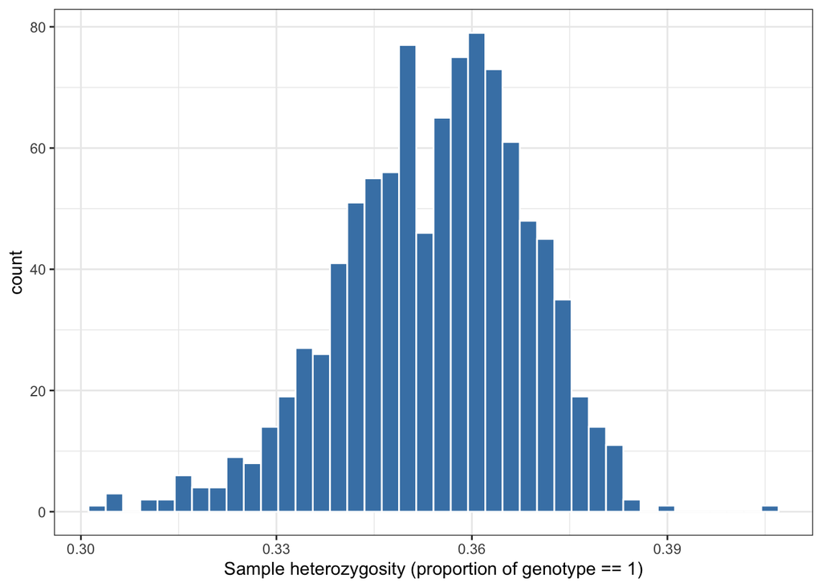

```r
sample_qc %>%
  ggplot(aes(x = het_rate)) +
  geom_histogram(bins = 40, fill = "steelblue", color = "white") +
  theme_bw() +
  xlab("Sample heterozygosity (proportion of genotype == 1)")
```

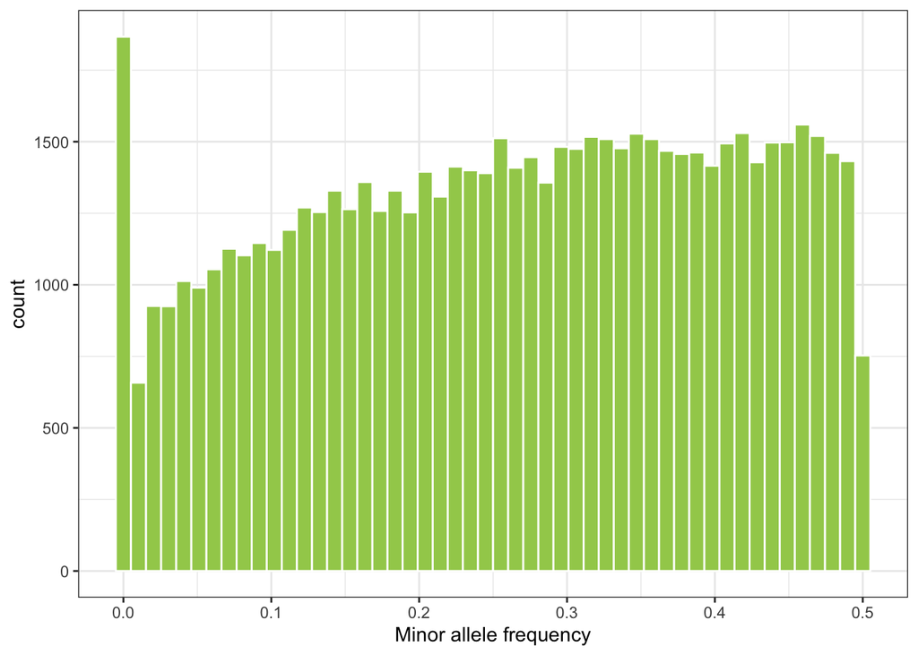

```r
snp_qc %>%
  ggplot(aes(x = maf)) +
  geom_histogram(bins = 50, fill = "darkolivegreen3", color = "white") +
  theme_bw() +
  xlab("Minor allele frequency")
```

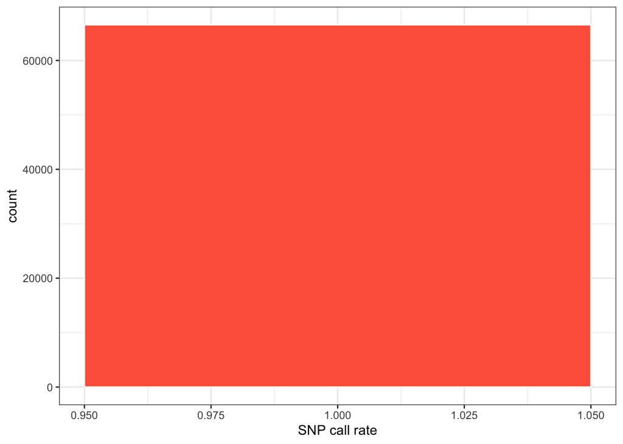

```r
snp_qc %>%
  ggplot(aes(x = call_rate)) +
  geom_histogram(bins = 30, fill = "tomato", color = "white") +
  theme_bw() +
  xlab("SNP call rate")
```

## Phenotype Coverage Check

```r
pcr_ids <- pcr_pheno %>%
  mutate(fish_n = as.integer(str_extract(sample_no, "(?<=-F)\\d+"))) %>%
  distinct(fish_n) %>%
  mutate(in_pcr = TRUE)

histo_ids <- histo_pheno %>%
  mutate(fish_n = as.integer(str_extract(id, "(?<=_)\\d+(?=\\s*\\()"))) %>%
  distinct(fish_n) %>%
  mutate(in_histo = TRUE)

pheno_overlap <- full_join(pcr_ids, histo_ids, by = "fish_n") %>%
  mutate(
    in_pcr = replace_na(in_pcr, FALSE),
    in_histo = replace_na(in_histo, FALSE),
    overlap_group = case_when(
      in_pcr & in_histo ~ "Both PCR and Histo",
      in_pcr & !in_histo ~ "PCR only",
      !in_pcr & in_histo ~ "Histo only"
    )
  )

pheno_overlap %>%
  count(overlap_group)
```

```
## # A tibble: 3 × 2
##   overlap_group          n
##   <chr>              <int>
## 1 Both PCR and Histo   300
## 2 Histo only           200
## 3 PCR only             200
```

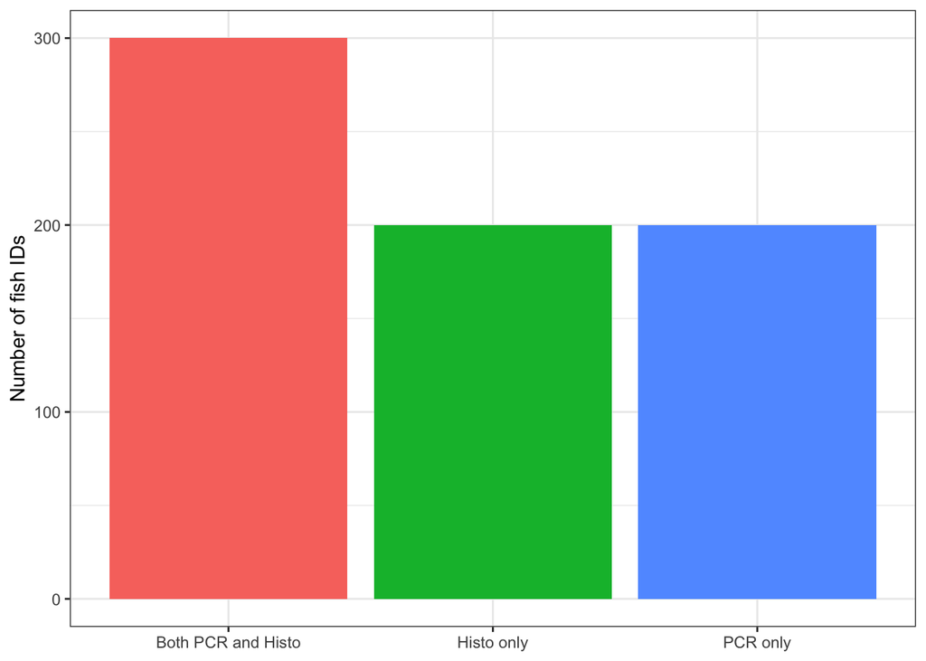

```r
pheno_overlap %>%
  ggplot(aes(x = overlap_group, fill = overlap_group)) +
  geom_bar(show.legend = FALSE) +
  theme_bw() +
  ylab("Number of fish IDs") +
  xlab(NULL)
```

```r
sum(as.character(pcr_pheno$sample_id) %in% fam$id)
```

```
## [1] 0
```

```r
sum(pcr_pheno$sample_no %in% fam$id)
```

```
## [1] 0
```

```r
sum(histo_pheno$id %in% fam$id)
```

```
## [1] 0
```

No direct string overlap is observed between phenotype IDs and PLINK `fam$id`. In this project, `Sheet1` serves as the external crosswalk to connect phenotype and pedigree/genotype IDs.